# Practical Machine Learning: Exercise

Julian Jordi

2021-09

## Summary

We analyze the Human Actitivty Recognition dataset provided by groupware [here](http://web.archive.org/web/20161224072740/http:/groupware.les.inf.puc-rio.br/har) to predict how well a particular exercise was performed.

## The Data

Let’s have a first look at the data

```r
library(tidyverse); library(caret); library(corrplot); library(parallel); library(doParallel)
set.seed(1000)
```

```r
training_raw = read_csv("pml-training.csv")
training_raw$classe = as.factor(training_raw$classe)
dim(training_raw)
```

```
## [1] 19622   160
```

So we have a total of 160 columns and 19622 observations In other words, 159 potential predictors for the variable `classe`, which we want to predict.

We have enough data to set aside a portion, say 20%, as a validation set. This will allow us to validate different models before deciding which on to use for the final prediction.

```r
partition = createDataPartition(y=training_raw$classe, p=0.8, list = F)
training = training_raw %>% slice(partition)
validation = training_raw %>% slice(-partition)
```

## Removing some Predictors

Before we start training models, let’s look if there are some obvious predictors which we do not need.

First of all, for many predictors, we have almost no measurements. Any prediction based on these would be highly unreliable. We therefore collect these columns for exclusion. This throws away 100 of the 159 possible predictors!

```r
min_required_observations = 1000  # we require at least 1000 valid measurements for a predictor to be included
ignored_columns = which(colSums(!is.na(training_raw) & training_raw != "") < min_required_observations)
length(ignored_columns)
```

```
## [1] 100
```

Second, we do not care so much about any of the `timestamp` columns. Event though it is entirely possible that the the day, or time of day, when a particular exercise is performance, does correlate with the *quality* with which it is performed, this should also be predictable by the other, concrete, measurements. In other words, we should get a good prediction even without these columns.

Also, notice the first column in the data set is just an index column which holds no predictive value. We exclude it also.

```r
timestamp_columns = names(training_raw) %>% grep(pattern = "timestamp")
index_column = 1
ignored_columns = c(ignored_columns, timestamp_columns, index_column)
training = training %>% select(!all_of(ignored_columns))
validation = validation %>% select(!all_of(ignored_columns))
```

Also, if we find very high correlation between any pair of the remaining predictors (at least numerical ones), we might exclude some redundant ones and avoid overfitting.

Indeed, we do find some pockets of highly correlated features:

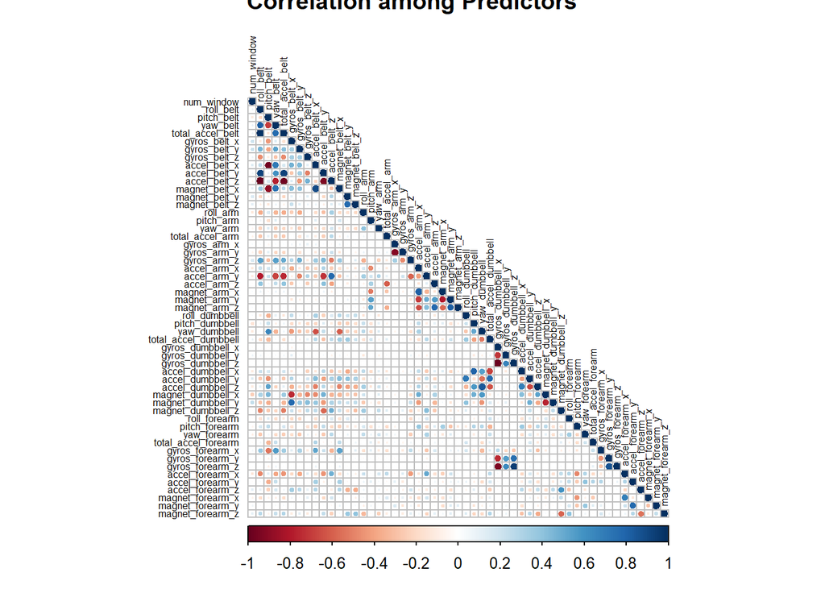

```r
numeric_columns = which(sapply(training, is.numeric))
correlation_matrix = cor(training[,numeric_columns])
corrplot(correlation_matrix, type = "lower", tl.cex = 0.5, tl.col = 'black', title = "Correlation among Predictors")
```

Caret’s `findCorrelation` function gives us the columns which we should remove to reduce pair-wise correlations. At this point, it is unclear if removing these columns make the model better and/or faster. But, as it turns out, we can leave them out and still achieve very high prediction accuracy.

```r
columns_to_remove = findCorrelation(correlation_matrix, exact=TRUE)
print(paste("removing columns", paste(columns_to_remove, collapse = ", "), "due to high correlation (>0.9) with one other columns"))
```

```
## [1] "removing columns 11, 2, 10, 9, 32, 34, 19 due to high correlation (>0.9) with one other columns"
```

```r
training_uncorrelated = training %>% select(!all_of(columns_to_remove))
validation_uncorrelated = validation %>% select(!all_of(columns_to_remove))
```

## Model Building

This kind of problem seems to be well-suited to random forest type and/or boosted models. The reasoning for this is that such models can account for complex if-else-then relationships between predictors.

We therefore train two models: a pure random forest, and a boosted model based on decision trees.

We use the caret package to train both models, as this allows us to profit from the built-in parameter tuning. For the random forest, caret will determine the most useful predictors to avoid overfitting. For the boosted decision trees, it will select an appropriate number of boosting iterations and depth of the individual trees.

To shorten training time, we use parallel processing and use 5-fold cross-validation as resampling technique. This is less computationally intensive than the default bootstrapping method. But, as it turns out, the accuracy of the produced models is still quite satisfactory.

```r
trainParallelCrossValidation = trainControl(allowParallel = T, method = "cv", number = 5) # use 5-fold cross validation for resampling
cluster <- makeCluster(detectCores() - 2)
registerDoParallel(cluster)
```

### Training a Random Forest

Train a random forest by using `method="rf"`.

```r
random_forest_fit = train(classe ~ ., method="rf", data = training_uncorrelated, trControl = trainParallelCrossValidation)
random_forest_fit
```

```
## Random Forest
##
## 15699 samples
##    48 predictor
##     5 classes: 'A', 'B', 'C', 'D', 'E'
##
## No pre-processing
## Resampling: Cross-Validated (5 fold)
## Summary of sample sizes: 12560, 12558, 12560, 12559, 12559
## Resampling results across tuning parameters:
##
##   mtry  Accuracy   Kappa
##    2    0.9942671  0.9927480
##   27    0.9968789  0.9960519
##   52    0.9935663  0.9918616
##
## Accuracy was used to select the optimal model using the largest value.
## The final value used for the model was mtry = 27.
```

The final model uses 500 trees and the 27 most important predictors.

```r
random_forest_fit$finalModel$ntree
```

```
## [1] 500
```

```r
random_forest_fit$finalModel$mtry
```

```
## [1] 27
```

### Training Boosted Decision Trees

This model uses the `gbm` package to build a boosted model based on decision trees.

After training an initial model, we realized accuracy increases sharply with increasing number of boosting iterations, and it is very low for interaction depths 1 and 2. We therefore adapt a non-default caret tuning grid, leaving out interaction depth 1, as well as models with only 50 iterations.

```r
gbmGrid <-  expand.grid(interaction.depth = c(2, 3, 5), # depth 1 is not needed
                        n.trees = (2:6)*50, # 50 iterations are not needed
                        shrinkage = 0.1, # same as default
                        n.minobsinnode = 10) # same as default

boosted_trees_fit = train(classe ~ ., method="gbm", data=training_uncorrelated, verbose=F, trControl = trainParallelCrossValidation, tuneGrid = gbmGrid)
stopCluster(cluster)
registerDoSEQ()
boosted_trees_fit
```

```
## Stochastic Gradient Boosting
##
## 15699 samples
##    48 predictor
##     5 classes: 'A', 'B', 'C', 'D', 'E'
##
## No pre-processing
## Resampling: Cross-Validated (5 fold)
## Summary of sample sizes: 12560, 12558, 12561, 12559, 12558
## Resampling results across tuning parameters:
##
##   interaction.depth  n.trees  Accuracy   Kappa
##   2                  100      0.9424802  0.9272181
##   2                  150      0.9661759  0.9572064
##   2                  200      0.9785971  0.9729230
##   2                  250      0.9864955  0.9829164
##   2                  300      0.9910183  0.9886387
##   3                  100      0.9726098  0.9653418
##   3                  150      0.9867504  0.9832385
##   3                  200      0.9924832  0.9904917
##   3                  250      0.9958592  0.9947624
##   3                  300      0.9971334  0.9963741
##   5                  100      0.9922286  0.9901696
##   5                  150      0.9964963  0.9955684
##   5                  200      0.9984073  0.9979855
##   5                  250      0.9990443  0.9987912
##   5                  300      0.9991718  0.9989524
##
## Tuning parameter 'shrinkage' was held constant at a value of 0.1
##
## Tuning parameter 'n.minobsinnode' was held constant at a value of 10
## Accuracy was used to select the optimal model using the largest value.
## The final values used for the model were n.trees = 300, interaction.depth =
##  5, shrinkage = 0.1 and n.minobsinnode = 10.
```

The following plot illustrates our reasoning for allowing larger tree depths and number of boosting iterations than caret does by default (3 and 150, respectively). In particular when the max tree depth is kept small, increasing the number of iterations above 150 greatly helps accuracy.

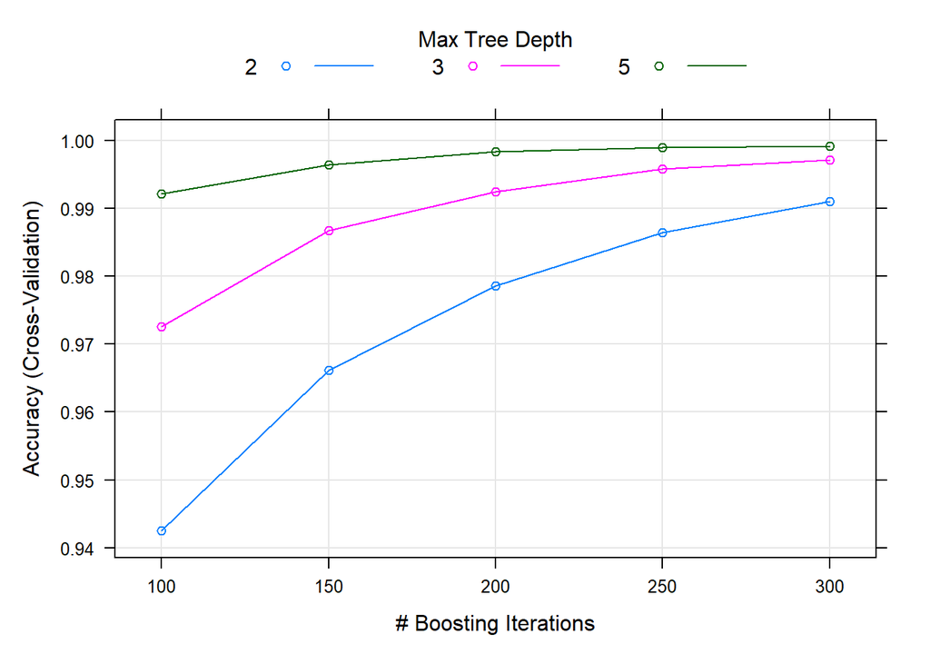

```r
plot(boosted_trees_fit)
```

## Use of Cross Validation

Cross validation is used by the caret package automatically during training of the models to select the most promising model parameter values.

In order to speed up the training, we switched from the standard bootstrapping resampling to 5-fold cross validation. In other words, caret built models for each parameter combination in the tuning grid (for random forest, there is only one tuning parameter: the number of used predictors `mtry`), trains these models on the subset without the withheld samples of the current fold, and predicts the withheld samples. It does this on each of the five folds.

Finally, caret selects the best model (i.e. parameter combination) as the one with the highest *average prediction accuracy* on the five folds (different quality metrics can be specified, but we did not).

## Expected Out of Sample Error and Model Selection

We use the validation set, which we set aside in the beginning, to estimate the out of sample error.

### Random Forest Model

```r
predict(random_forest_fit, validation_uncorrelated) %>% confusionMatrix(validation_uncorrelated$classe)
```

```
## Confusion Matrix and Statistics
##
##           Reference
## Prediction    A    B    C    D    E
##          A 1116    1    0    0    0
##          B    0  756    1    0    0
##          C    0    2  682    3    0
##          D    0    0    1  640    0
##          E    0    0    0    0  721
##
## Overall Statistics
##
##                Accuracy : 0.998
##                  95% CI : (0.996, 0.9991)
##     No Information Rate : 0.2845
##     P-Value [Acc > NIR] : < 2.2e-16
##
##                   Kappa : 0.9974
##
##  Mcnemar's Test P-Value : NA
##
## Statistics by Class:
##
##                      Class: A Class: B Class: C Class: D Class: E
## Sensitivity            1.0000   0.9960   0.9971   0.9953   1.0000
## Specificity            0.9996   0.9997   0.9985   0.9997   1.0000
## Pos Pred Value         0.9991   0.9987   0.9927   0.9984   1.0000
## Neg Pred Value         1.0000   0.9991   0.9994   0.9991   1.0000
## Prevalence             0.2845   0.1935   0.1744   0.1639   0.1838
## Detection Rate         0.2845   0.1927   0.1738   0.1631   0.1838
## Detection Prevalence   0.2847   0.1930   0.1751   0.1634   0.1838
## Balanced Accuracy      0.9998   0.9979   0.9978   0.9975   1.0000
```

### Boosted Trees Model

```r
predict(boosted_trees_fit, validation_uncorrelated) %>% confusionMatrix(validation_uncorrelated$classe)
```

```
## Confusion Matrix and Statistics
##
##           Reference
## Prediction    A    B    C    D    E
##          A 1116    1    0    0    0
##          B    0  758    0    0    2
##          C    0    0  684    0    0
##          D    0    0    0  643    0
##          E    0    0    0    0  719
##
## Overall Statistics
##
##                Accuracy : 0.9992
##                  95% CI : (0.9978, 0.9998)
##     No Information Rate : 0.2845
##     P-Value [Acc > NIR] : < 2.2e-16
##
##                   Kappa : 0.999
##
##  Mcnemar's Test P-Value : NA
##
## Statistics by Class:
##
##                      Class: A Class: B Class: C Class: D Class: E
## Sensitivity            1.0000   0.9987   1.0000   1.0000   0.9972
## Specificity            0.9996   0.9994   1.0000   1.0000   1.0000
## Pos Pred Value         0.9991   0.9974   1.0000   1.0000   1.0000
## Neg Pred Value         1.0000   0.9997   1.0000   1.0000   0.9994
## Prevalence             0.2845   0.1935   0.1744   0.1639   0.1838
## Detection Rate         0.2845   0.1932   0.1744   0.1639   0.1833
## Detection Prevalence   0.2847   0.1937   0.1744   0.1639   0.1833
## Balanced Accuracy      0.9998   0.9990   1.0000   1.0000   0.9986
```

In particular, we should be able to classify all 20 testing observations correctly.

## Results on the Test Set

We predict the following `classe` for the observations in the test set:

```r
read_csv("pml-testing.csv") %>% predict(object = boosted_trees_fit)
```

```
##  [1] B A B A A E D B A A B C B A E E A B B B
## Levels: A B C D E
```